# Estadística I

Clase 11: Momentos de Una Variable

Autor/a

Afiliación

M.Sc. José Miguel Avendaño I.

Universidad Central de Venezuela- Escuela de Economía. 2025-1

Fecha de publicación

8 de mayo de 2025

## ¿Qué son los Momentos?

- Son medidas que nos dan información sobre las características de un conjunto de datos.
- Nos ayudan a entender dónde se concentran los datos, cuánto se dispersan y qué forma tienen.
- Algunos son: la media, la varianza, la asimetría y la curtosis.

los momentos nos dan diferentes “perspectivas” de los datos, más allá del simple promedio.

## El Primer Momento: La Media ( $\bar{X}$ )

La **media** es el promedio de los datos. Nos dice dónde está el “centro” de nuestros valores.

**Ejemplo :** El salario promedio de los empleados de una empresa.

## El Segundo Momento Central: La Varianza ( $S^2$ )

La **varianza** mide cuánto se dispersan los datos alrededor de la media. Una varianza alta significa que los datos están muy dispersos; una varianza baja, que están más agrupados.

$s^2=\frac{\sum_{i=1}^{n}(xi−\bar{x})^2}{n-1}$

La **desviación estándar** (s) es la raíz cuadrada de la varianza y se interpreta más fácilmente.

$s=\sqrt{s^2}$

[figure not shown]

## **Ejemplo Varianza:**

La varianza del rendimiento diario de las acciones indica qué tan volátil es el precio.

## El Tercer Momento Central: Asimetría

La **asimetría** nos dice si la distribución de los datos es simétrica o si está “cargada” hacia un lado.

- **Asimetría positiva (sesgado a la derecha):** La cola derecha es más larga.
- **Asimetría negativa (sesgado a la izquierda):** La cola izquierda es más larga.
- **Asimetría cercana a cero:** Distribución aproximadamente simétrica.

## **Coeficiente de Asimetría Muestral**

El **coeficiente de asimetría muestral** ( $A_s$ ) oscila entre -1 y 1

Su comportamiento, cuando la distribución está sesgada, está dado porque la media tienda a situarse con respecto a la moda al mismo lado que la cola más larga ubicarse

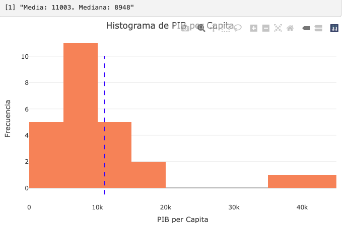

## Cálculo de Coeficiente de Asimetría

Se puede calcular de distintas formas.

1. Primer coeficiente de Pearson

   $Sesgo=\frac{Media-Moda}{desviación\,típica}=\frac{\bar{X}-moda}{s}$
2. Segundo coeficiente de Pearson

   $Sesgo = \frac{3(Media-Mediana)}{desviación\,típica}=\frac{3(\bar{X}-mediana)}{s}$

   En el segundo caso se omite el uso de la “moda”

## Cálculo de Coeficiente de Asimetría /2

3. Coeficiente de Sesgo Cuartílico

   $Sesgo=\frac{(Q_3 - Q_2)-(Q_2-Q_1)}{Q_3-Q_1}= \frac{Q_3-2Q_2+Q_1}{Q_3-Q_1}$
4. Coeficiente de Sesgo percentílico

   $Sesgo=\frac{(P_{90}-P_{50})- (P_{50}-P_{10})}{P_{90}-P_{10}}=\frac{P_{90}-2P_{50}+P_{10}}{P_{90}-P_{10}}$

## **Ejemplo Asimetría:**

La distribución de los ingresos en un país puede tener asimetría positiva si hay pocos individuos con ingresos muy altos.

## El Cuarto Momento: Curtosis

La **curtosis** nos indica qué tan “puntiaguda” es la distribución y qué tan pesadas son sus “colas” (los extremos).

- **Leptocúrtica:** Más puntiaguda y con colas más pesadas que una distribución normal.
- **Platicúrtica:** Más achatada y con colas más ligeras que una distribución normal.
- **Mesocúrtica:** Similar a una distribución normal.

El **coeficiente de curtosis muestral** ($K_u$) también se puede calcular. *Próxima clase*

## **Ejemplo Curtosis:**

La rentabilidad de algunos activos financieros puede tener alta curtosis, lo que significa que ocurren eventos extremos (grandes ganancias o pérdidas) con más frecuencia de lo que se esperaría en una distribución normal.

## Distribución Mesocúrtica

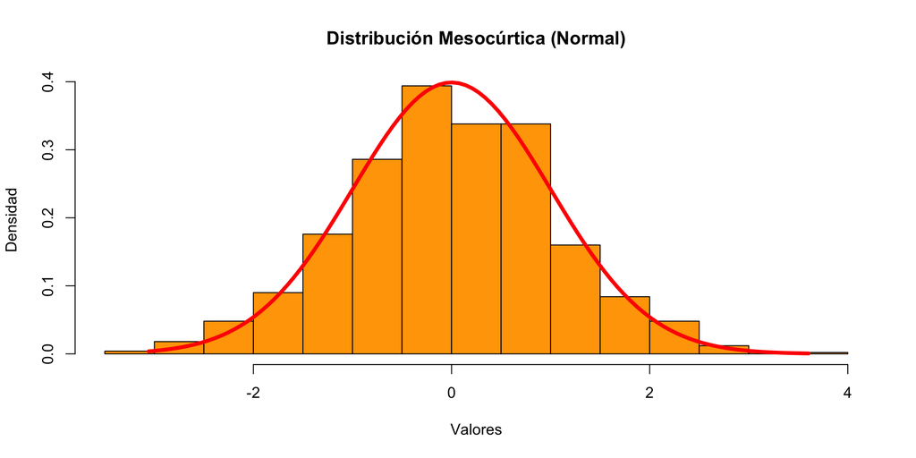

## Distribución Leptocúrtica

Colas más pesadas y pico más alto

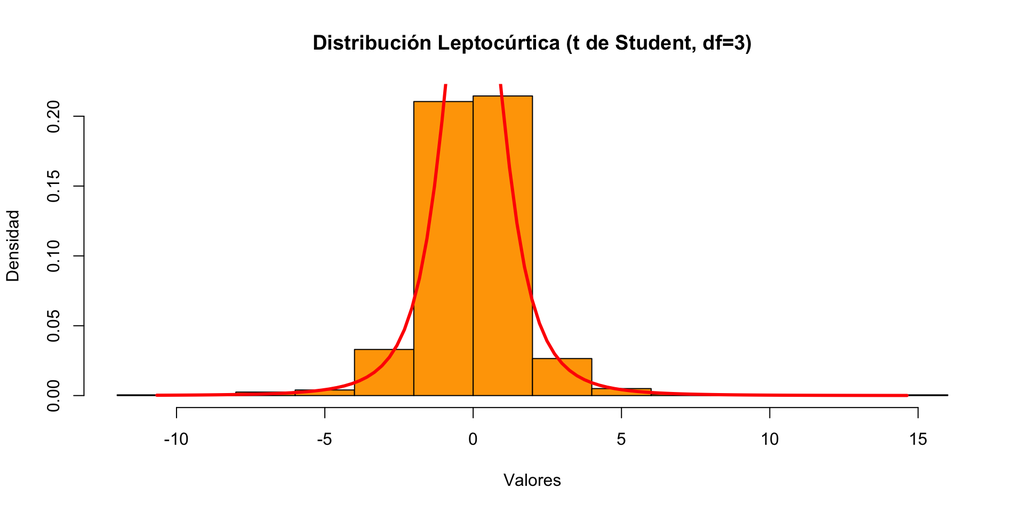

## Distribución Platicúrtica

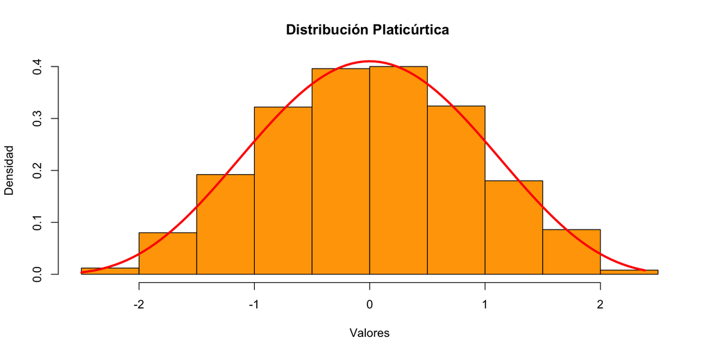

## Resumen de los Momentos

| **Momento** | **¿Qué mide?** |
| --- | --- |
| **Media (** $\bar{X}$ ) | El centro de los datos |
| **Varianza (** $s^2$ ) | La dispersión de los datos |
| **Asimetría (** $A_s$ **)** | Si la distribución está sesgada hacia un lado |
| **Curtosis (** $K_u$ ) | El “apuntamiento” y el grosor de las colas |